# Analyzing topics

This notebook illustrates how we transform the raw daily time series of sign-adjusted topics before estimating the daily factor model. Additionally, it also calculates principal component estimates of transformed series and analyzes their correlation with quarterly GDP.

```r
rm(list = ls())
library(ggplot2)
library(lubridate)
library(dplyr)
library(tidyr)
library(fredmdr)
library(bundesbank)
library(tibble)
library(ggsci)
```

## Load topics

```r
df_raw <- read.csv("./topics/sign_adjusted_daily_topics_format.csv")

# add date and weekday variable
df_raw %>%
  mutate(date = make_date(year = df_raw$year,
                         month = df_raw$month,
                         day = df_raw$day),
         weekday = wday(date, label = T),
         quarter = ceiling(month / 3)) %>%
  select(year, quarter, month, day, weekday, date, everything()) -> df_topics

# get rid of raw df
rm(df_raw)

# inspect first rows of df_topics
head(df_topics)
```

|  | year | quarter | month | day | weekday | date | T0 | T1 | T2 | T3 | T4 | T5 | T6 | T7 | T8 | T9 | T10 | T11 | T12 | T13 | T14 | T15 | T16 | T17 | T18 | T19 | T20 | T21 | T22 | … |
| --- | --- | --- | --- | --- | --- | --- | --- | --- | --- | --- | --- | --- | --- | --- | --- | --- | --- | --- | --- | --- | --- | --- | --- | --- | --- | --- | --- | --- | --- | --- |
| 1 | 1991 | 1 | 1 | 1 | Di | 1991-01-01 | 0.0050312826 | 5.031283e-03 | 0.0002346194 | 0.0004953076 | 0.01744004 | -0.0008081335 | 0.002685089 | -0.0003388947 | 0.0107664234 | 0.0007038582 | -0.006126173 | 0.0005474453 | 0.0026850886 | 0.0014859228 | 0.0037799791 | 0.0037799791 | 9.932221e-03 | 8.081335e-04 | 0.0005474453 | -0.0002346194 | 8.602711e-04 | 0.0006517205 | 0.021193952 | … |
| 2 | 1991 | 1 | 1 | 2 | Mi | 1991-01-02 | 0.0067219153 | 3.934371e-04 | 0.0001757911 | 0.0077264356 | -0.01135945 | 0.0021346057 | 0.007475306 | 0.0003097271 | -0.0128662314 | 0.0016993136 | 0.011526871 | 0.0001590491 | 0.0222250126 | 0.0084295999 | 0.0007785033 | 0.0034404822 | 8.379374e-03 | -9.768960e-03 | -0.0005775992 | -0.0001088230 | 7.533903e-05 | 0.0027875439 | 0.007609242 | … |
| 3 | 1991 | 1 | 1 | 3 | Do | 1991-01-03 | 0.0002159004 | 2.413005e-04 | 0.0002667005 | 0.0176149352 | -0.01238252 | 0.0002667005 | 0.008623317 | -0.0009271019 | -0.0095123190 | 0.0002921006 | 0.001612903 | 0.0012573025 | 0.0032131064 | -0.0181483363 | 0.0002921006 | -0.0073025146 | 1.256033e-02 | -5.321311e-03 | -0.0005461011 | 0.0022987046 | 8.890018e-05 | 0.0004191008 | 0.011849124 | … |
| 4 | 1991 | 1 | 1 | 4 | Fr | 1991-01-04 | 0.0006244109 | 8.246937e-05 | 0.0031927427 | 0.0231503299 | -0.02364515 | 0.0025329877 | -0.003970311 | 0.0006950990 | 0.0011427898 | 0.0004830349 | 0.004677191 | -0.0008836004 | 0.0009071631 | 0.0046065033 | 0.0002474081 | 0.0028393025 | -1.176956e-02 | 8.246937e-05 | 0.0019674835 | 0.0004830349 | 7.422243e-04 | 0.0005065975 | 0.006892083 | … |
| 5 | 1991 | 1 | 1 | 5 | Sa | 1991-01-05 | 0.0008658970 | -1.110124e-04 | 0.0001110124 | 0.0205373002 | 0.01289964 | -0.0001110124 | -0.007260213 | 0.0036190053 | -0.0001998224 | 0.0001110124 | 0.004862345 | 0.0022868561 | -0.0022424512 | -0.0013543517 | 0.0001554174 | -0.0014431616 | -4.240675e-03 | 4.063055e-03 | -0.0013987567 | 0.0015319716 | -1.554174e-04 | 0.0004662522 | -0.003974245 | … |
| 6 | 1991 | 1 | 1 | 6 | So | 1991-01-06 | 0.0001702259 | 1.702259e-04 | 0.0002011761 | 0.0186474776 | 0.03554627 | 0.0004178273 | 0.012952646 | 0.0030485918 | 0.0004178273 | 0.0002630764 | 0.002584339 | 0.0005416280 | 0.0041627979 | 0.0006035283 | 0.0003559270 | 0.0002011761 | 7.737543e-05 | 7.892293e-04 | 0.0007582792 | 0.0015939338 | 1.392758e-04 | 0.0002011761 | 0.022856701 | … |

The earlier version of the analysis, which only used the SZ dataset, had missing days for Sundays and bank holidays when no newspapers were published (e.g., Twelfth Night or 6.1.1994). This required consideration of different modeling approaches:

1. Formulating the model at the daily frequency with `NA` for Sundays and bank holidays
2. Formulating the model at the weekdaily frequency with `NA` for bank holidays
3. Formulating the model under the assumption that a week contains six days with `NA` for bank holidays

However, with the inclusion of the dpa dataset, there are no missing days, and we now have a complete daily time series, making these considerations obsolete. The transformations are performed on the complete dataset without any gaps.

## Preprocessing and transformations

The following plot shows a representative sign-adjusted topic series. It is extremely noisy and characterized by a slow-moving trend (but not necessarily linear!). In this section, we illustrate how to adjust the series in order to estimate the factor model at the daily frequency.

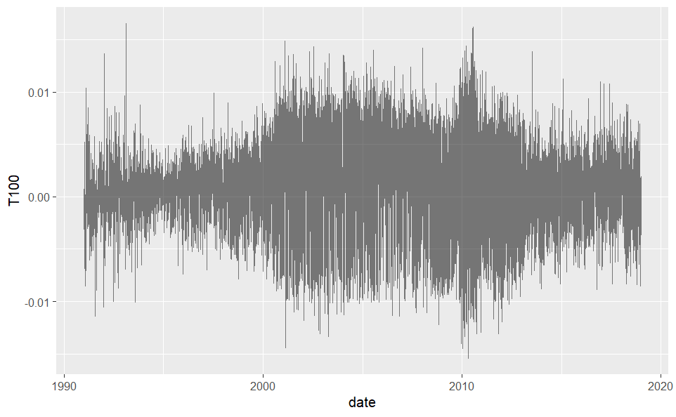

```r
ggplot(df_topics, aes(x = date, y = T100))+geom_line(alpha = 0.5)
```

Before proceeding, we standardize the original topics. This should not have any impact on the smoothing or de-trending. It merely ensures that the original series and the final (de-trended) series are on the same scale. Note, however, that this implies that the final series will in general not have unit standard deviation. When preparing the data for the estimation, smoothing and de-trending can be performed on the original data and the resulting final series is standardized.

```r
# select only sign-adjusted topics
dat_orig <- select(df_topics, -year, -quarter, -month, -day, -date, -weekday)

# standardize
dat <- scale(dat_orig)
```

### Removing outlier

In line with the nowcasting/forecasting literature, we define outlier as those observations that are more than 10 interquartiles ranges from the median. Note that this is a very conservative definition!

```r
dt_outl <- function(y, aalpha)
{
  return(abs((y - median(y, na.rm = T))) > aalpha * IQR(y, na.rm = T))
}

ind_outl <- apply(dat, c(2), dt_outl, aalpha = 10)

# number of outliers?
sum(ind_outl)
```

```
[1] 3717
```

In total, there are 3717 observations classified as outlier. Set these to `NA`. These missing values will be overwritten, when we smooth the series and de-trend them. Therefore we should reimpose the pattern of `NA` obtained at this stage and not use observations that were originally classified as outlier.

```r
dat_rmoutl <- dat
dat_rmoutl[ind_outl] <- NA
```

Visualize series with the most outliers

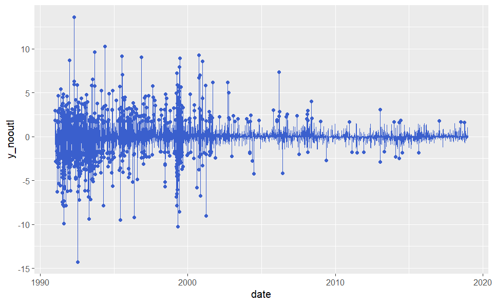

```r
i <- which.max(apply(ind_outl, c(2), sum))
tmp <- array(NA, nrow(dat))
tmp[ind_outl[, i]] <- dat[ind_outl[, i], i]

df_plot <- data.frame(date = df_topics$date,
                      y_nooutl = dat[, i],
                      y_outl = tmp)

ggplot(df_plot)+
  geom_line(aes(x = date, y = y_nooutl), col = "royalblue3")+
  geom_point(aes(x = date, y = y_outl), col = "royalblue3")
```

```r
rm(df_plot, i, tmp)
```

### Smoothing the raw topics

To smooth the topics, we calculate a 60-day backward looking moving average.

`rollmean` function that calculates the recursive $K$-th order rolling mean, i.e. $\hat{y}_t = \frac{1}{K} \sum_{k=0}^K y_{t-k}$. Allows for `NA` in the series.

```r
rollmean <- function(x, k){
  xroll <- array(NA, c(length(x)))
  for (t in seq(k, length(x)))
    xroll[t] <- mean(x[(t-k+1):t], na.rm = TRUE)

  return(xroll)
}
```

```r
# moving average
K <- 60
dat_ma <- apply(dat_rmoutl, c(2), rollmean, k = K)
```

### Removing trends

`bw_filter` function that calculates the bi-weight filter as in [Stock and Watson (2012)](https://www.princeton.edu/~mwatson/papers/Stock_Watson_Disentangling_BPEA_2012.pdf) and [Stock and Watson (2016)](https://www.princeton.edu/~mwatson/papers/Stock_Watson_DFM_HOM_030916.pdf). This removes long-run trends in the series but is more flexible than a linear time trend. While in principle two-sided, the filter becomes increasingly one-sided when approaching the endpoints. The function allows for `NA` in the series but only at the beginning!

```r
bw_filter <- function(y, bw)
{
  # compute un-normalized weights
  j <- seq(-bw, bw, 1)
  omeg = (1 - (j/bw) ^ 2) ^ 2

  # check for NA's in y
  n_NA <- sum(is.na(y))
  y_noNA <- y[(n_NA + 1) : length(y)]
  Nt <- length(y_noNA)

  # loop over t
  tau <- mat.or.vec(length(y_noNA), 1)
  for (t in 1 : length(y_noNA)) {
    # case distinction
    if (t <= bw) {

      indY <- c(1 : (2 * bw - (bw - t)))
      indOmeg <- c((bw - t + 2):(2 * bw + 1))
      kap <- 1 / ( sum(omeg[indOmeg]))
      tau[ t ] <- kap * omeg[indOmeg] %*% y_noNA[indY]

    } else if (t > (Nt - bw)) {

      indY <- c((t - bw) : Nt)
      indOmeg <- c(1 : (bw + 1 + (Nt - t)))
      kap <- 1 / ( sum( omeg[indOmeg] ) )
      tau[t] <- kap * omeg[indOmeg] %*% y_noNA[indY]

    } else {

      indY <- seq(t - bw, t + bw, 1)
      indOmeg <- c( 1 : (2 * bw + 1))
      kap <- 1 / (sum(omeg[indOmeg]))
      tau[t] <- kap * omeg[indOmeg] %*% y_noNA[indY]
    }
  }
  return(c(rep(NA, times = n_NA), tau))
}
```

```r
# bi-weight filter
dat_bw <- apply(dat_ma, c(2), bw_filter, bw = 600)

# de-trended topics
dat_trafo <- dat_ma - dat_bw
```

### Plot selected topics

```r
df_orig <- as.data.frame(dat_rmoutl)
df_orig$date <- df_topics$date
df_orig %>%
  pivot_longer(cols = -date, names_to = "topics", values_to = "vals") %>%
  mutate(series = "original") -> df_orig

df_trafo <- as.data.frame(dat_trafo)
df_trafo$date <- df_topics$date
df_trafo %>%
  pivot_longer(cols = -date, names_to = "topics", values_to = "vals") %>%
  mutate(series = "final") -> df_trafo

df_ma <- as.data.frame(dat_ma)
df_ma$date <- df_topics$date
df_ma %>%
  pivot_longer(cols = -date, names_to = "topics", values_to = "vals") %>%
  mutate(series = "smoothed") -> df_ma

df_bw <- as.data.frame(dat_bw)
df_bw$date <- df_topics$date
df_bw %>%
  pivot_longer(cols = -date, names_to = "topics", values_to = "vals") %>%
  mutate(series = "filtered") -> df_bw

# merge into one df
df_plot <- rbind(df_ma, df_bw)
df_plot <- rbind(df_plot, df_orig)
df_plot <- rbind(df_plot, df_trafo)

# rm df's
rm(df_ma, df_bw, df_orig, df_trafo)

# convert series to factor and reorder levels
df_plot$series <- as.factor(df_plot$series)
df_plot$series = factor(df_plot$series,levels(df_plot$series)[c(3, 4, 1, 2)])
```

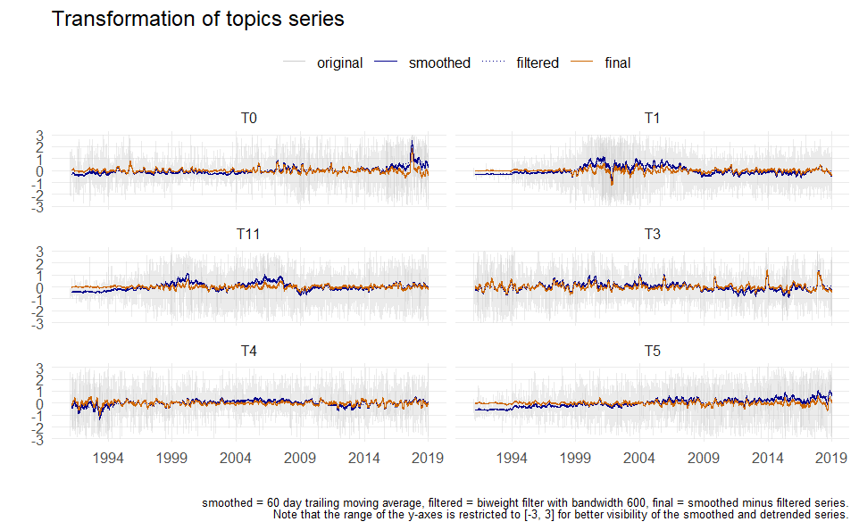

```r
# plot
ylim_uppr <- 3
ylim_lowr <- -ylim_uppr

ggplot(filter(df_plot, topics %in% c("T0", "T1", "T3", "T4", "T5", "T11")),
       aes(x = date, y = vals,
           group = series,
           col = series,
           linetype = series,
           alpha = series
           )
       )+
  geom_line()+
  scale_color_manual(name = element_blank(),
                     values = c("filtered" = "blue4",
                                "smoothed" = "blue4",
                                "original" = "gray80",
                                "final" = "darkorange3"))+
  scale_linetype_manual(name = element_blank(),
                        values = c("filtered" = "dotted",
                                   "smoothed" = "solid",
                                   "original" = "solid",
                                   "final" = "solid"))+
  scale_alpha_manual(name = element_blank(),
                     guide = 'none',
                     values = c("filtered" = 1,
                                "smoothed" = 1,
                                "original" = 0.4,
                                "final" = 1))+
  labs(x = "", y = "",
       title = "Transformation of topics series",
       caption = paste0("smoothed = 60 day trailing moving average, filtered = biweight filter with bandwidth 600, final = smoothed minus filtered series.\nNote that the range of the y-axes is restricted to [", ylim_lowr, ", ", ylim_uppr, "] for better visibility of the smoothed and detrended series."))+
  scale_x_date(date_breaks = "5 years", date_labels = "%Y")+
  scale_y_continuous(breaks = seq(ylim_lowr, ylim_uppr, by = 1), limits = c(ylim_lowr, ylim_uppr))+
  facet_wrap(~ topics , ncol = 2)+
  theme_minimal()+
  theme(legend.position = "top",
        panel.grid.minor = element_blank(),
        #panel.grid.major = element_blank(),
        plot.caption = element_text(size = 7))
```

Save plot as pdf

```r
ggsave(filename = "./topics_trafos.pdf", width = 20, height = 15, units = "cm")
```

## Analysis of the transformed series

### Plot all transformed time series

```r
stepsize <- 2
pdf(file="plot_all_trafo_topic.pdf", paper = "a4r", width = 10, height = 8)
for (i in seq(1, ncol(dat_trafo), by = stepsize))
{
  matplot(df_topics$date, scale(dat_trafo[, i:(i+(stepsize-1))]),
          type = "l", main = paste0("T", i-1, " to ", i+(stepsize-2)), # topics start counting at 0!!!!
          col = c("cornflowerblue", "darkorange1", "darkorchid3"),
          ylab = "", xlab = "", lty = rep(1, stepsize))
  legend("topright",
       legend = paste0("T", seq(i-1, i+(stepsize-2))), # topics start counting at 0!!!!
       col = c("cornflowerblue", "darkorange1", "darkorchid3"),
       lty= rep(1, stepsize), cex= 1, box.lty = 0, y.intersp=2, bg="transparent")
}

dev.off()
```

### Principal components of (transformed) sign-adjusted topics

Reimpose pattern original pattern of missings

```r
dat_pca <- dat_trafo
dat_pca[ind_outl] <- NA
```

Drop some topics

```r
dat_pca <- dat_pca[, -c(6), drop = F]
```

Calculate eigenvalues and plot cumulative share of explained variance

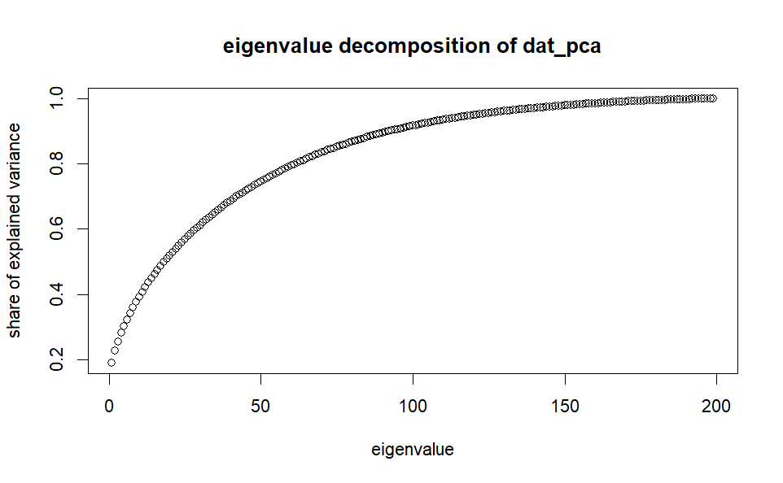

```r
eigvals_pca <- eigen(cor(dat_pca, use = "complete.obs"), only.values = T)
plot(seq(1, length(eigvals_pca$values)),
     cumsum(eigvals_pca$values) / sum(eigvals_pca$values),
     xlab = "eigenvalue", ylab = "share of explained variance",
     main = "eigenvalue decomposition of dat_pca")
```

PCA based on EM algorithm following Stock and Watson (2002). Manually set number of factors to 10!

```r
pca <- f_emalg(scale(dat_pca), Nr_max = 10, Niter = 50, ic = "none",  print_iter = TRUE)
```

```
iteration: 1, current error: 999.0000000, number of factors selected: 10
iteration: 2, current error: 0.0004538, number of factors selected: 10
iteration: 3, current error: 0.0000243, number of factors selected: 10
iteration: 4, current error: 0.0000032, number of factors selected: 10
```

Plot PCs

```r
cols <- rep(c("cornflowerblue",
              "darkorange1",
              "darkorchid3",
              "darkolivegreen4",
              "brown"), times = 2)
ltys <- rep(c(1, 2), each = 5)
pdf(file="plot_pc_trafo.pdf", paper = "a4r", width = 10, height = 8)
matplot(df_topics$date, pca$f,
        type = "l", lty = ltys, col = cols,
        main = "First 10 principal components of transformed topics",
        ylab = "", xlab = "")
legend(as.Date("2004-01-01"), 2.0,
       legend = paste0("PC", seq(1, 10)),
       col = cols,
       lty= ltys, cex= 1, box.lty = 0, y.intersp=2, bg="transparent", ncol = 5)
dev.off()
```

Clean up workspace!

```r
rm(eigvals_pca, dat_pca, pca)
```

### Correlation analysis

#### Correlation between transformed topics

Calculate the correlation between the transformed sign-adjusted topics

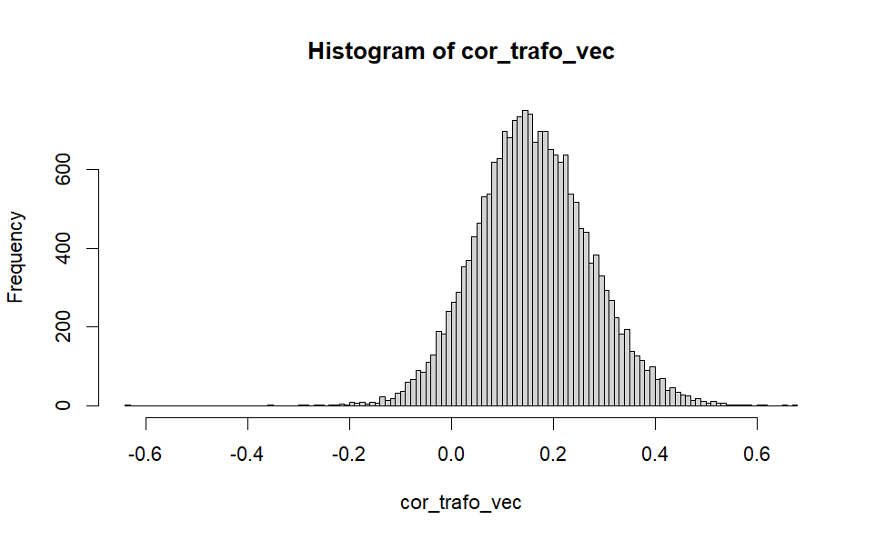

```r
cor_trafo <- cor(dat_trafo, use = "complete.obs")
cor_trafo_vec <- cor_trafo[lower.tri(cor_trafo)]
hist(cor_trafo_vec, breaks = 100)
```

#### Correlation with quarterly GDP growth

Aggregate transformed sign-adjusted topics to quarterly frequency

```r
df_trafo <- cbind(df_topics[, 1:4], as.data.frame(dat_trafo))

df_trafo %>%
  pivot_longer(cols = -c(year, quarter, month, day),
               names_to = "topic",
               values_to = "vals") %>%
  group_by(topic, year, quarter) %>%
  summarise(avg_vals = mean(vals, na.rm = T)) %>%
  pivot_wider(id_cols = c(year, quarter),
              names_from = topic,
              values_from = avg_vals) -> df_trafo_Q
```

```r
series <- "BBKRT.Q.DE.Y.A.AG1.CA010.A.I"
df_gdp <- getSeries("BBKRT.Q.DE.Y.A.AG1.CA010.A.I") # calendar and seasonally adjusted GDP
```

```
Downloading data from Bundesbank ... done
```

```r
# select last vintage and convert dates to column
df_gdp %>%
  select(tail(names(.), 1)) %>%
  rownames_to_column(var = "date") %>%
  mutate(year = as.numeric(substr(date, 1, 4)),
         month = as.numeric(substr(date, 6, 7)) + 1,
         quarter = ceiling(month/3),
         date = make_date(year = year, month = month, day = 15) # middle of the quarter, e.g. 15.2. for Q1
         )-> df_gdp

# adjust name of series
names(df_gdp)[2] <- "gdp"

# calculate annualized quarterly growth rate
df_gdp$d_gdp <- c(NA, 400 * diff(log(df_gdp$gdp)))

# filter to match sample of transformed topics
df_gdp <- df_gdp[df_gdp$year >= 1991 & df_gdp$year <= 2018, ]
```

Calculate correlation between topics and GDP

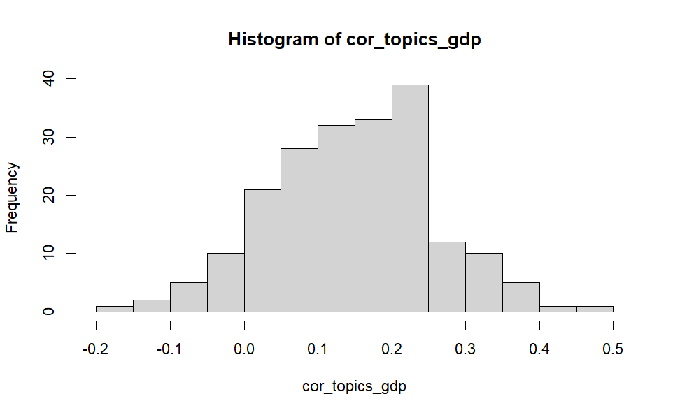

```r
cor_topics_gdp <- cor(cbind(as.matrix(df_trafo_Q[, -c(1:2)]), df_gdp$d_gdp), use = "complete.obs")

# last row contains correlations of topics with GDP growth
cor_topics_gdp <- cor_topics_gdp[nrow(cor_topics_gdp), 1:(ncol(cor_topics_gdp) - 1)]

# histogram
hist(cor_topics_gdp, breaks = 20)
```

```r
# sort topics
as.data.frame(cor_topics_gdp) %>%
  rownames_to_column(var = "topic") %>%
  mutate(abs_cor = abs(cor_topics_gdp)) %>%
  arrange(desc(abs_cor)) %>%
  head(10)
```

|  | topic | cor_topics_gdp | abs_cor |
| --- | --- | --- | --- |
| 1 | T27 | 0.4746361 | 0.4746361 |
| 2 | T52 | 0.4008141 | 0.4008141 |
| 3 | T81 | 0.3951839 | 0.3951839 |
| 4 | T127 | 0.3934952 | 0.3934952 |
| 5 | T11 | 0.3662692 | 0.3662692 |
| 6 | T138 | 0.3614062 | 0.3614062 |
| 7 | T129 | 0.3597741 | 0.3597741 |
| 8 | T131 | 0.3355335 | 0.3355335 |
| 9 | T136 | 0.3337733 | 0.3337733 |
| 10 | T100 | 0.3191643 | 0.3191643 |

Plot 5 topics with the highest correlation

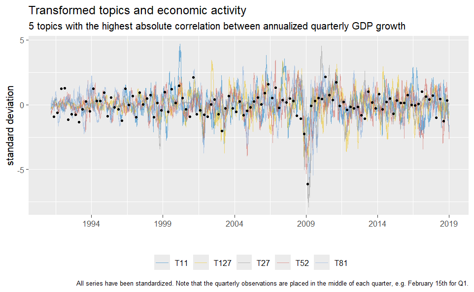

```r
# sort by absolute correlation
top_topics <- sort(abs(cor_topics_gdp), decreasing = TRUE)
high_corr_topics <- names(top_topics[1:5])

#high_corr_topics <- c("T10", "T0", "T44", "T36", "T21") # automate!

cbind(data.frame(date = df_topics$date), scale(dat_trafo))  %>%
  pivot_longer(cols = -date, names_to = "topic", values_to = "vals") %>%
  filter(topic %in% high_corr_topics) %>%
  filter(date >= "1991-01-01" & date <= "2018-12-31") -> df_plot_topics

df_gdp %>%
  mutate(d_gdp_stand = (d_gdp - mean(d_gdp, na.rm = T)) / sd(d_gdp, na.rm = T)) %>%
  filter(date >= "1991-01-01" & date <= "2018-12-31") -> df_plot_gdp

ggplot()+
  geom_line(mapping = aes(x = date, y = vals, group = topic, color = topic),
            data = df_plot_topics, alpha = 0.5)+
  geom_point(mapping = aes(x = date, y = d_gdp_stand),
             data = df_plot_gdp, size = 1, col = "black")+
  scale_color_jco(name = element_blank())+
  scale_x_date(date_breaks = "5 years", date_labels = "%Y")+
  labs(y = "standard deviation", x = "", title = "Transformed topics and economic activity",
       subtitles = "5 topics with the highest absolute correlation between annualized quarterly GDP growth",
       caption = "All series have been standardized. Note that the quarterly observations are placed in the middle of each quarter, e.g. February 15th for Q1.")+
  theme(legend.position = "bottom",
        plot.caption = element_text(size = 7))
```

Save plot

```r
ggsave(filename = "plot_highcorr_topics_gdp.pdf", width = 20, height = 15, units = "cm")
```